# Effect of Covid on the Price of several Species

2022-02-25

```r
library(MASS)
library(carData)
library(car)
library(fitdistrplus)
library(goft)
```

# 1 Read data

First Mediterranean data:

```r
library(dplyr)
data_M<- read.csv("MED_2017-21.csv",sep=";",dec=",")
head(data_M)
```

```
##   Covid       date       specie     euros      kgs
## 1   No  02/01/2017 ANE-BOQUERON    830.60   111.69
## 2   No  02/01/2017  PIL-SARDINA 129131.37 54232.49
## 3   No  03/01/2017 ANE-BOQUERON    749.13    77.00
## 4   No  03/01/2017  PIL-SARDINA  81008.61 45355.49
## 5   No  04/01/2017  PIL-SARDINA  42228.58 21619.01
## 6   No  05/01/2017 ANE-BOQUERON     28.98     6.85
```

```r
data_M=subset(data_M,data_M$Covid!="After state of alarm 2")
data_M$euros=data_M$euros/data_M$kgs
e=data_M%>%
     group_by(specie) %>%
     summarise(Mean = mean(euros, na.rm = TRUE))
e$Mean=round(e$Mean,1);e
```

```
## # A tibble: 28 x 2
##    specie                       Mean
##    <chr>                       <dbl>
##  1 ANE-BOQUERON                  3.2
##  2 ARA-GAMBA ROJA O RAYADO      37.6
##  3 BFT-ATUN ROJO                 9.4
##  4 BLT-MELVA                     2
##  5 BOG-BOGA                      0.4
##  6 BON-BONITO O BONITO DEL SUR   5
##  7 CET-ACEDIA                    7.9
##  8 DPS-GAMBA                    12.9
##  9 FOR-BROTOLA DE ROCA           7.4
## 10 FRZ-MELVAS                    2.3
## # ... with 18 more rows
```

```r
e=e[c(11,14,13,17,22,27,28,19,25,18),]
l=data_M %>%
     group_by(specie) %>%
     summarise(Mean = mean(kgs, na.rm = TRUE))
l$Mean=round(l$Mean);l
```

```
## # A tibble: 28 x 2
##    specie                       Mean
##    <chr>                       <dbl>
##  1 ANE-BOQUERON                 7882
##  2 ARA-GAMBA ROJA O RAYADO       528
##  3 BFT-ATUN ROJO                1869
##  4 BLT-MELVA                    2897
##  5 BOG-BOGA                     1455
##  6 BON-BONITO O BONITO DEL SUR   393
##  7 CET-ACEDIA                      5
##  8 DPS-GAMBA                    1449
##  9 FOR-BROTOLA DE ROCA            31
## 10 FRZ-MELVAS                   4602
## # ... with 18 more rows
```

```r
l=l[c(11,14,13,17,22,27,28,19,25,18),]
```

Second Golf of Cádiz data:

```r
data_A<- read.csv("ATL_2017-21.csv",sep=";",dec=",")
head(data_A)
```

```
##   Covid       date       specie    euros      kgs
## 1    NO 09/01/2017  PIL-SARDINA 37655.47 15055.34
## 2    NO 10/01/2017  PIL-SARDINA 41208.45 29884.03
## 3    NO 11/01/2017 ANE-BOQUERON 22767.86  4288.60
## 4    NO 11/01/2017  PIL-SARDINA 13636.23  7347.15
## 5    NO 12/01/2017 ANE-BOQUERON 51289.61 10756.45
## 6    NO 12/01/2017  PIL-SARDINA  2415.19  1624.13
```

```r
data_A=subset(data_A,data_A$Covid!="After state of alarm 2")
data_A$euros=data_A$euros/data_A$kgs
e=data_A%>%
     group_by(specie) %>%
     summarise(Mean = mean(euros, na.rm = TRUE))
e$Mean=round(e$Mean,1);e
```

```
## # A tibble: 27 x 2
##    specie                       Mean
##    <chr>                       <dbl>
##  1 ANE-BOQUERON                  2.6
##  2 ARA-GAMBA ROJA O RAYADO      36.5
##  3 BFT-ATUN ROJO                13.2
##  4 BLT-MELVA                     1.8
##  5 BOG-BOGA                      0.5
##  6 BON-BONITO O BONITO DEL SUR   3.3
##  7 CET-ACEDIA                    9.1
##  8 DPS-GAMBA                     9.1
##  9 FOR-BROTOLA DE ROCA           5.6
## 10 FRZ-MELVAS                    1.8
## # ... with 17 more rows
```

```r
e=e[c(11,14,13,16,21,26,27,18,24,17),]
l=data_A %>%
     group_by(specie) %>%
     summarise(Mean = mean(kgs, na.rm = TRUE))
l$Mean=round(l$Mean);l
```

```
## # A tibble: 27 x 2
##    specie                       Mean
##    <chr>                       <dbl>
##  1 ANE-BOQUERON                29424
##  2 ARA-GAMBA ROJA O RAYADO       330
##  3 BFT-ATUN ROJO               13644
##  4 BLT-MELVA                      87
##  5 BOG-BOGA                     1228
##  6 BON-BONITO O BONITO DEL SUR   656
##  7 CET-ACEDIA                    649
##  8 DPS-GAMBA                   12854
##  9 FOR-BROTOLA DE ROCA            84
## 10 FRZ-MELVAS                    110
## # ... with 17 more rows
```

```r
l=l[c(11,14,13,16,21,26,27,18,24,17),]
```

# 2 Golf of Cádiz

## 2.1 Trachurus mediterraneus

```r
data1=subset(data_A,data_A$specie=="HMM-JUREL BLANCO")
```

### 2.1.1 Exploratory analysis

#### 2.1.1.1 Price by covid category (boxplot)

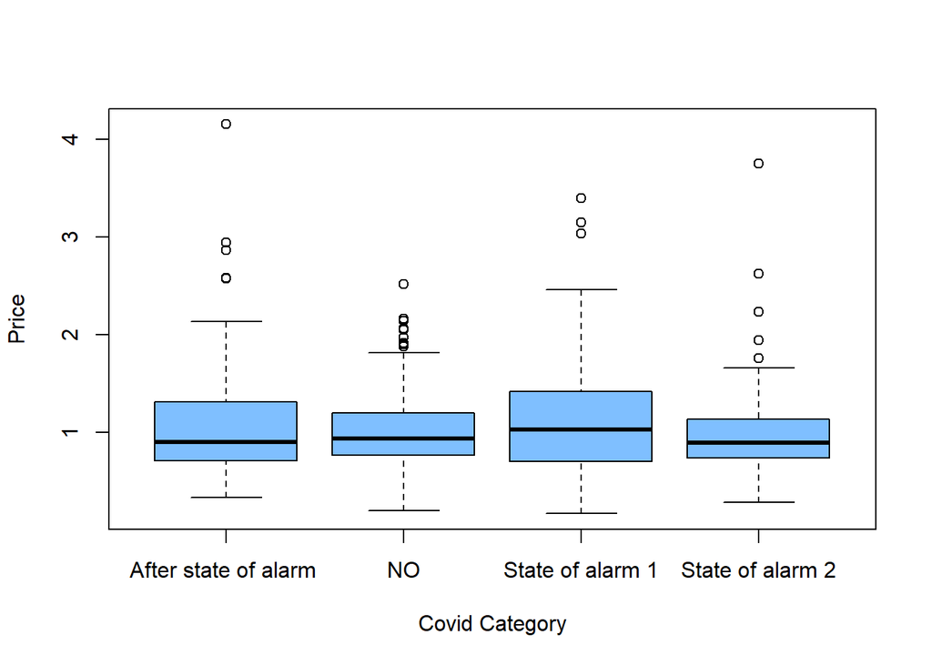

```r
boxplot(data1$euros~data1$Covid, col = rgb(0, 0.5, 1, alpha = 0.5),xlab="Covid Category",ylab="Price")
```

### 2.1.2 Abundance by covid category (boxplot)

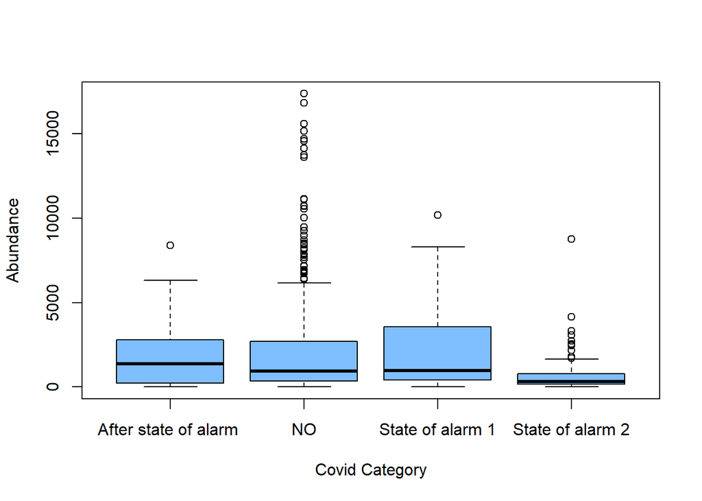

```r
boxplot(data1$kgs~data1$Covid, col = rgb(0, 0.5, 1, alpha = 0.5),xlab="Covid Category",ylab="Abundance")
```

#### 2.1.2.1 Price vs Abundance (scatter plot)

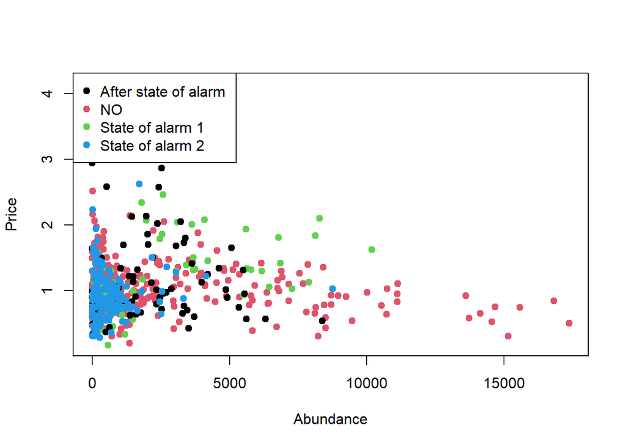

```r
plot(data1$kgs,data1$euros,
     pch = 19,
     col = factor(data1$Covid),xlab="Abundance",ylab = "Price")

# Legend
legend("topleft",
       legend = levels(factor(data1$Covid)),
       pch = 19,
       col = factor(levels(factor(data1$Covid))))
```

```r
cor.test(data1$kgs,data1$euros)
```

```
##
##  Pearson's product-moment correlation
##
## data:  data1$kgs and data1$euros
## t = 0.22408, df = 634, p-value = 0.8228
## alternative hypothesis: true correlation is not equal to 0
## 95 percent confidence interval:
##  -0.0688932  0.0865833
## sample estimates:
##         cor
## 0.008898828
```

Is gamma a correct distribution for the response variable PRICE?

```r
summary(data1$euros)
```

```
##    Min. 1st Qu.  Median    Mean 3rd Qu.    Max.
##  0.1696  0.7482  0.9249  1.0278  1.2160  4.1565
```

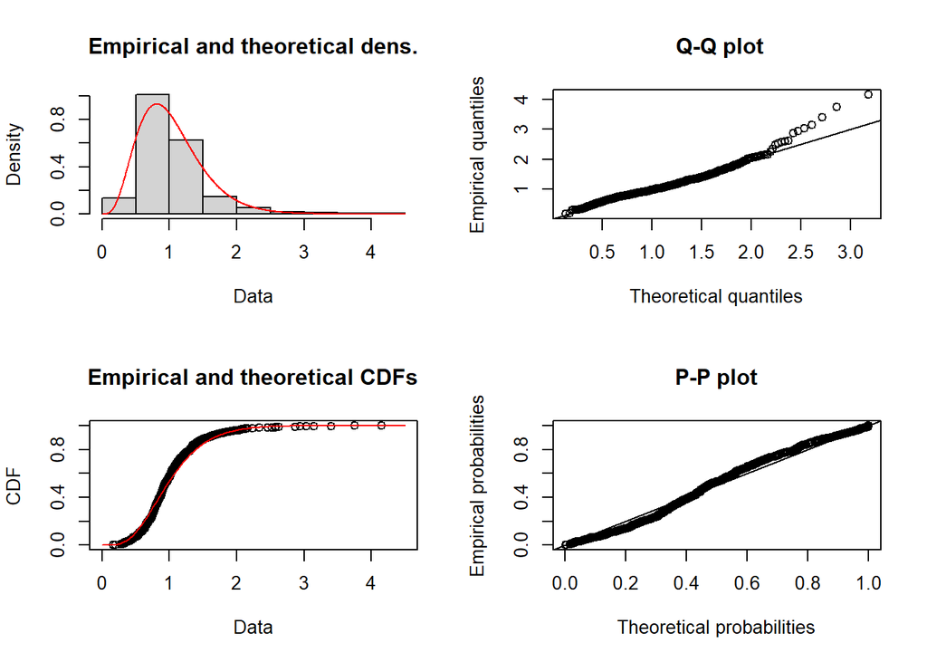

```r
a=fitdist(data1$euros, distr = "gamma",start=list(shape = 1, rate = 2), lower = -1,method = "mme")
plot(a)
```

```r
ks.test(na.omit(data1$euros), "pgamma", a$estimate[1],a$estimate[2])
```

```
##
##  One-sample Kolmogorov-Smirnov test
##
## data:  na.omit(data1$euros)
## D = 0.067915, p-value = 0.005663
## alternative hypothesis: two-sided
```

```r
gamma_test(data1$euros)
```

```
##
##  Test of fit for the Gamma distribution
##
## data:  data1$euros
## V = 8.8088, p-value = 4.702e-10
```

Is gamma a correct distribution for the response variable ABUNDANCE?

```r
summary(data1$kgs)
```

```
##     Min.  1st Qu.   Median     Mean  3rd Qu.     Max.
##     1.06   263.39   751.37  1871.45  2215.45 17371.10
```

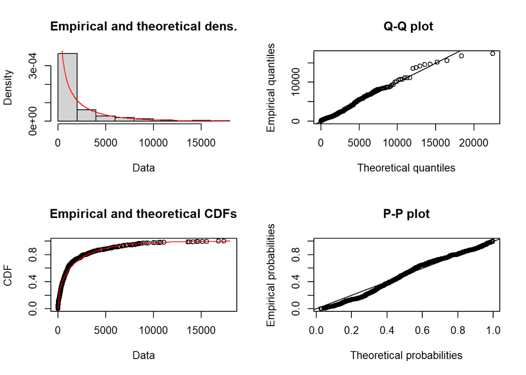

```r
a=fitdist(data1$kgs, distr = "gamma",start=list(shape = 1, rate = 2), lower = -1,method = "mme")
plot(a)
```

```r
ks.test(na.omit(data1$kgs), "pgamma", a$estimate[1],a$estimate[2])
```

```
##
##  One-sample Kolmogorov-Smirnov test
##
## data:  na.omit(data1$kgs)
## D = 0.088063, p-value = 0.000104
## alternative hypothesis: two-sided
```

```r
gamma_test(data1$kgs)
```

```
##
##  Test of fit for the Gamma distribution
##
## data:  data1$kgs
## V = 3.6031, p-value = 0.01084
```

### 2.1.3 Regression model

```r
x=as.factor(data1$Covid)
table(x)
```

```
## x
## After state of alarm                     NO      State of alarm 1
##                    92                   319                    77
##      State of alarm 2
##                   148
```

```r
y=as.numeric(data1$euros)
x=relevel(x, ref = "NO")
z=data1$kgs

Model<-glm((y)~x,family=Gamma(link=log))
cooksd <- cooks.distance(Model)
influential <- cooksd[(cooksd > (3 * mean(cooksd, na.rm = TRUE)))]
influential=as.numeric(names(influential))
y=y[-influential]
xaux=x[-influential]
Model<-glm((y)~xaux,family=Gamma(link=log))
summary(Model)
```

```
##
## Call:
## glm(formula = (y) ~ xaux, family = Gamma(link = log))
##
## Deviance Residuals:
##      Min        1Q    Median        3Q       Max
## -1.27122  -0.24551  -0.04635   0.19138   0.89446
##
## Coefficients:
##                            Estimate Std. Error t value Pr(>|t|)
## (Intercept)               -0.006651   0.019532  -0.341   0.7336
## xauxAfter state of alarm  -0.046445   0.043785  -1.061   0.2892
## xauxState of alarm 1       0.048556   0.049372   0.983   0.3258
## xauxState of alarm 2      -0.075003   0.034985  -2.144   0.0324 *
## ---
## Signif. codes:  0 '***' 0.001 '**' 0.01 '*' 0.05 '.' 0.1 ' ' 1
##
## (Dispersion parameter for Gamma family taken to be 0.1213122)
##
##     Null deviance: 75.920  on 599  degrees of freedom
## Residual deviance: 75.027  on 596  degrees of freedom
## AIC: 371.56
##
## Number of Fisher Scoring iterations: 4
```

```r
Model.aux<-glm((z)~x,family=Gamma(link=log))

cooksd <- cooks.distance(Model.aux)
influential <- cooksd[(cooksd > (3 * mean(cooksd, na.rm = TRUE)))]
influential=as.numeric(names(influential))
z=z[-influential]
xaux=x[-influential]
Model.aux<-glm((z)~xaux,family=Gamma(link=log))
summary(Model.aux)
```

```
##
## Call:
## glm(formula = (z) ~ xaux, family = Gamma(link = log))
##
## Deviance Residuals:
##     Min       1Q   Median       3Q      Max
## -3.5094  -1.2675  -0.5205   0.3599   2.2594
##
## Coefficients:
##                           Estimate Std. Error t value Pr(>|t|)
## (Intercept)                7.50737    0.06413  117.07  < 2e-16 ***
## xauxAfter state of alarm  -0.29184    0.13829   -2.11  0.03526 *
## xauxState of alarm 1      -0.41611    0.15357   -2.71  0.00693 **
## xauxState of alarm 2      -1.37995    0.11436  -12.07  < 2e-16 ***
## ---
## Signif. codes:  0 '***' 0.001 '**' 0.01 '*' 0.05 '.' 0.1 ' ' 1
##
## (Dispersion parameter for Gamma family taken to be 1.246081)
##
##     Null deviance: 1115.44  on 588  degrees of freedom
## Residual deviance:  967.86  on 585  degrees of freedom
## AIC: 9516.2
##
## Number of Fisher Scoring iterations: 6
```

## 2.2 Trachurus picturatus

```r
data1=subset(data_A,data_A$specie=="JAA-JUREL NEGRO")
```

### 2.2.1 Exploratory analysis

#### 2.2.1.1 Price by covid category (boxplot)

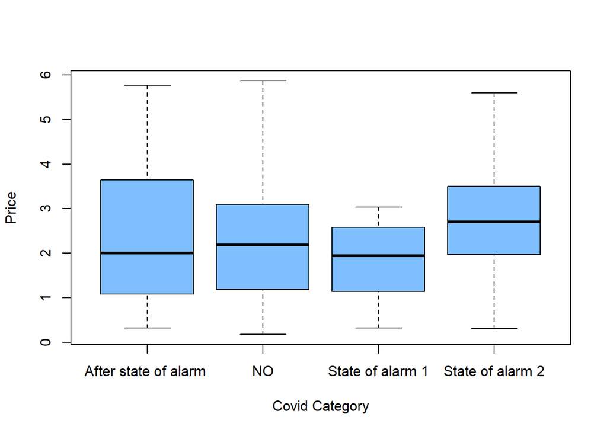

```r
boxplot(data1$euros~data1$Covid, col = rgb(0, 0.5, 1, alpha = 0.5),xlab="Covid Category",ylab="Price")
```

### 2.2.2 Abundance by covid category (boxplot)

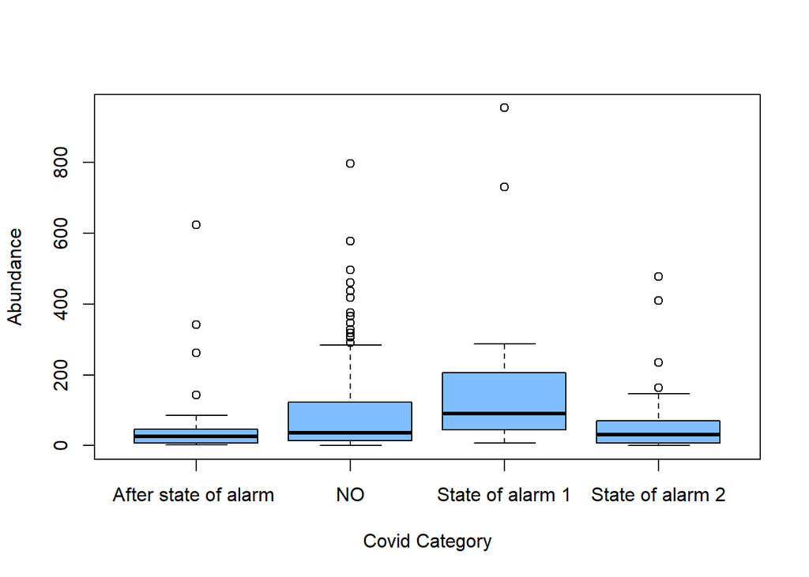

```r
boxplot(data1$kgs~data1$Covid, col = rgb(0, 0.5, 1, alpha = 0.5),xlab="Covid Category",ylab="Abundance")
```

#### 2.2.2.1 Price vs Abundance (scatter plot)

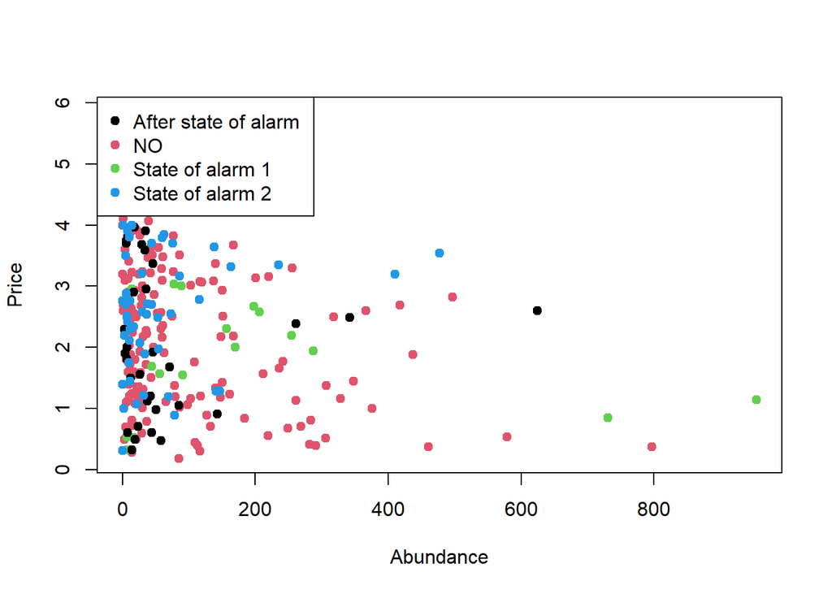

```r
plot(data1$kgs,data1$euros,
     pch = 19,
     col = factor(data1$Covid),xlab="Abundance",ylab = "Price")

# Legend
legend("topleft",
       legend = levels(factor(data1$Covid)),
       pch = 19,
       col = factor(levels(factor(data1$Covid))))
```

```r
cor.test(data1$kgs,data1$euros)
```

```
##
##  Pearson's product-moment correlation
##
## data:  data1$kgs and data1$euros
## t = -3.6334, df = 258, p-value = 0.0003374
## alternative hypothesis: true correlation is not equal to 0
## 95 percent confidence interval:
##  -0.3333400 -0.1017098
## sample estimates:
##        cor
## -0.2206335
```

Is gamma a correct distribution for the response variable PRICE?

```r
summary(data1$euros)
```

```
##    Min. 1st Qu.  Median    Mean 3rd Qu.    Max.
##   0.180   1.216   2.305   2.295   3.161   5.864
```

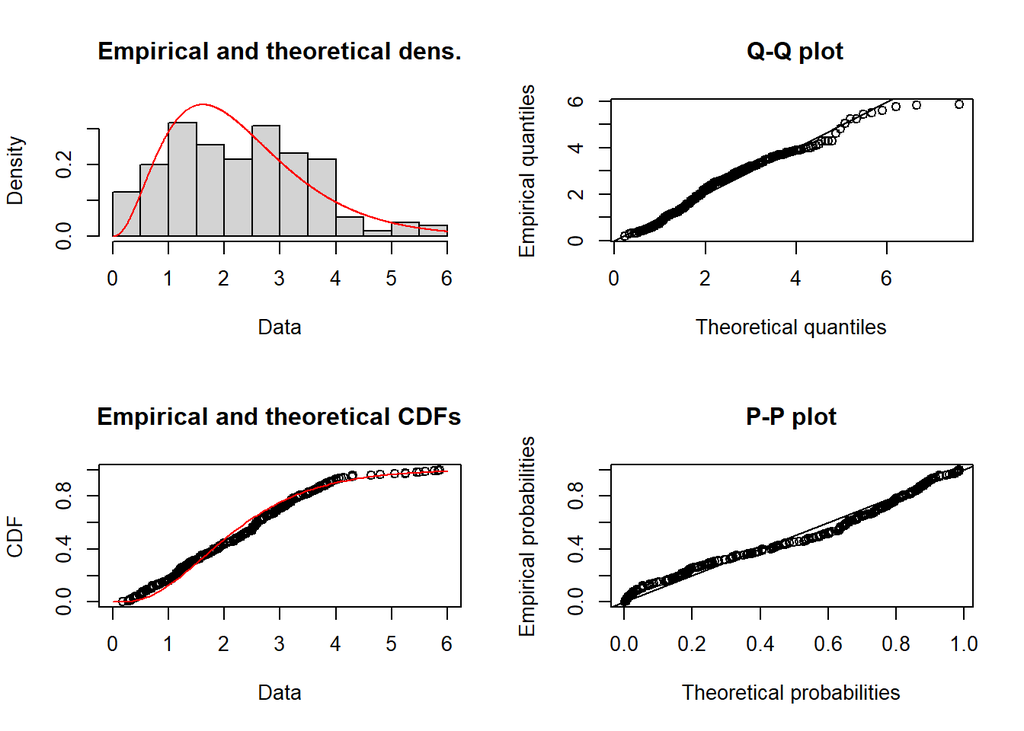

```r
a=fitdist(data1$euros, distr = "gamma",start=list(shape = 1, rate = 2), lower = -1,method = "mme")
plot(a)
```

```r
ks.test(na.omit(data1$euros), "pgamma", a$estimate[1],a$estimate[2])
```

```
##
##  One-sample Kolmogorov-Smirnov test
##
## data:  na.omit(data1$euros)
## D = 0.094406, p-value = 0.01942
## alternative hypothesis: two-sided
```

```r
gamma_test(data1$euros)
```

```
##
##  Test of fit for the Gamma distribution
##
## data:  data1$euros
## V = -4.0719, p-value = 0.003986
```

Is gamma a correct distribution for the response variable ABUNDANCE?

```r
summary(data1$kgs)
```

```
##    Min. 1st Qu.  Median    Mean 3rd Qu.    Max.
##    0.35   11.55   34.65   90.00  110.64  954.11
```

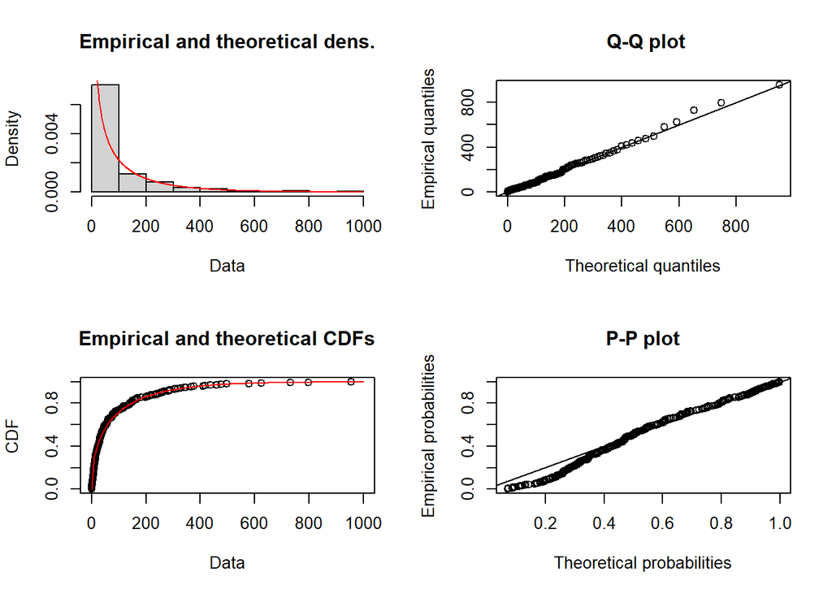

```r
a=fitdist(data1$kgs, distr = "gamma",start=list(shape = 1, rate = 2), lower = -1,method = "mme")
plot(a)
```

```r
ks.test(na.omit(data1$kgs), "pgamma", a$estimate[1],a$estimate[2])
```

```
##
##  One-sample Kolmogorov-Smirnov test
##
## data:  na.omit(data1$kgs)
## D = 0.12718, p-value = 0.000445
## alternative hypothesis: two-sided
```

```r
gamma_test(data1$kgs)
```

```
##
##  Test of fit for the Gamma distribution
##
## data:  data1$kgs
## V = 3.7197, p-value = 0.008533
```

### 2.2.3 Regression model

```r
x=as.factor(data1$Covid)
table(x)
```

```
## x
## After state of alarm                     NO      State of alarm 1
##                    35                   159                    17
##      State of alarm 2
##                    49
```

```r
y=as.numeric(data1$euros)
x=relevel(x, ref = "NO")
z=data1$kgs


Model<-glm((y)~x,family=Gamma(link=log))
cooksd <- cooks.distance(Model)
influential <- cooksd[(cooksd > (3 * mean(cooksd, na.rm = TRUE)))]
influential=as.numeric(names(influential))
y=y[-influential]
xaux=x[-influential]
Model<-glm((y)~xaux,family=Gamma(link=log))
summary(Model)
```

```
##
## Call:
## glm(formula = (y) ~ xaux, family = Gamma(link = log))
##
## Deviance Residuals:
##      Min        1Q    Median        3Q       Max
## -1.76744  -0.50521   0.01049   0.33158   1.05157
##
## Coefficients:
##                           Estimate Std. Error t value Pr(>|t|)
## (Intercept)                0.76303    0.03981  19.165   <2e-16 ***
## xauxAfter state of alarm   0.06918    0.10873   0.636   0.5253
## xauxState of alarm 1      -0.12862    0.16995  -0.757   0.4499
## xauxState of alarm 2       0.19142    0.08322   2.300   0.0223 *
## ---
## Signif. codes:  0 '***' 0.001 '**' 0.01 '*' 0.05 '.' 0.1 ' ' 1
##
## (Dispersion parameter for Gamma family taken to be 0.2456887)
##
##     Null deviance: 74.762  on 233  degrees of freedom
## Residual deviance: 73.147  on 230  degrees of freedom
## AIC: 716.67
##
## Number of Fisher Scoring iterations: 5
```

```r
Model.aux<-glm((z)~x,family=Gamma(link=log))

cooksd <- cooks.distance(Model.aux)
influential <- cooksd[(cooksd > (3 * mean(cooksd, na.rm = TRUE)))]
influential=as.numeric(names(influential))
z=z[-influential]
xaux=x[-influential]
Model.aux<-glm((z)~xaux,family=Gamma(link=log))
summary(Model.aux)
```

```
##
## Call:
## glm(formula = (z) ~ xaux, family = Gamma(link = log))
##
## Deviance Residuals:
##     Min       1Q   Median       3Q      Max
## -2.8075  -1.3670  -0.6110   0.3854   2.3747
##
## Coefficients:
##                           Estimate Std. Error t value Pr(>|t|)
## (Intercept)                4.42304    0.09329  47.414  < 2e-16 ***
## xauxAfter state of alarm  -1.01006    0.22611  -4.467 1.21e-05 ***
## xauxState of alarm 1       0.29388    0.31497   0.933 0.351720
## xauxState of alarm 2      -0.73502    0.19548  -3.760 0.000213 ***
## ---
## Signif. codes:  0 '***' 0.001 '**' 0.01 '*' 0.05 '.' 0.1 ' ' 1
##
## (Dispersion parameter for Gamma family taken to be 1.357532)
##
##     Null deviance: 431.61  on 248  degrees of freedom
## Residual deviance: 393.39  on 245  degrees of freedom
## AIC: 2578.2
##
## Number of Fisher Scoring iterations: 6
```

## 2.3 Trachurus trachurus

```r
data1=subset(data_A,data_A$specie=="HOM-JUREL")
```

### 2.3.1 Exploratory analysis

#### 2.3.1.1 Price by covid category (boxplot)

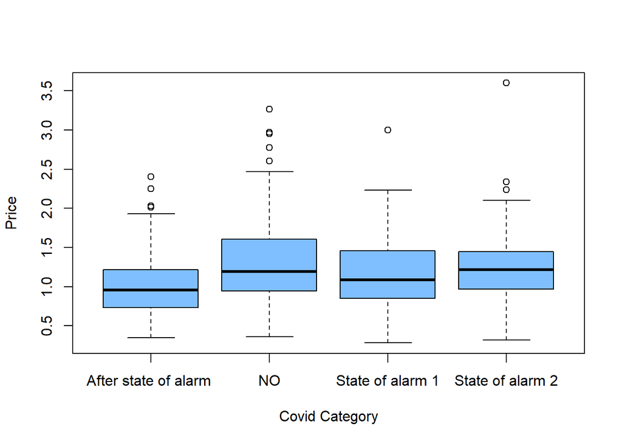

```r
boxplot(data1$euros~data1$Covid, col = rgb(0, 0.5, 1, alpha = 0.5),xlab="Covid Category",ylab="Price")
```

### 2.3.2 Abundance by covid category (boxplot)

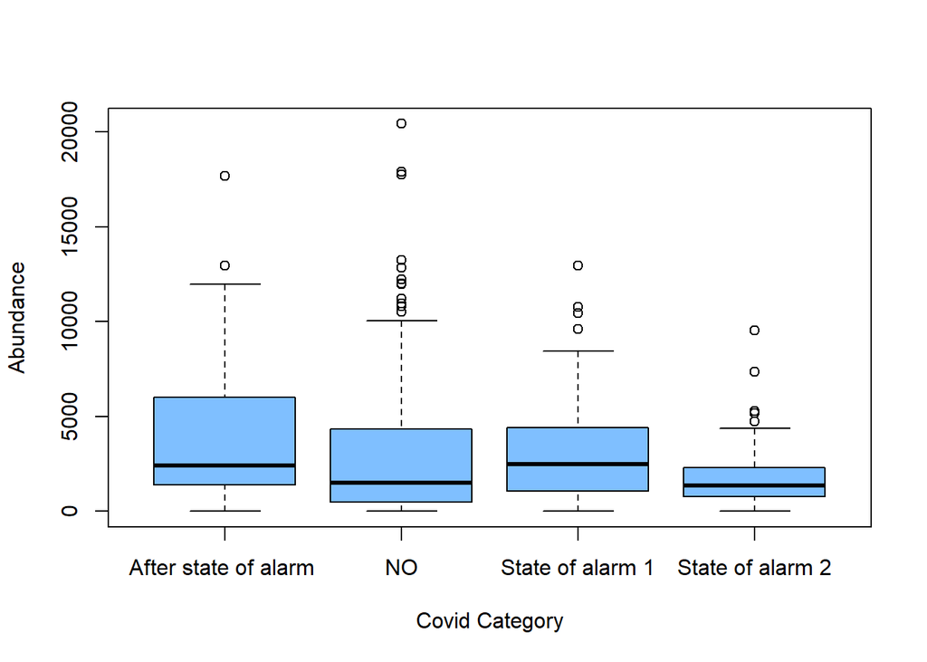

```r
boxplot(data1$kgs~data1$Covid, col = rgb(0, 0.5, 1, alpha = 0.5),xlab="Covid Category",ylab="Abundance")
```

#### 2.3.2.1 Price vs Abundance (scatter plot)

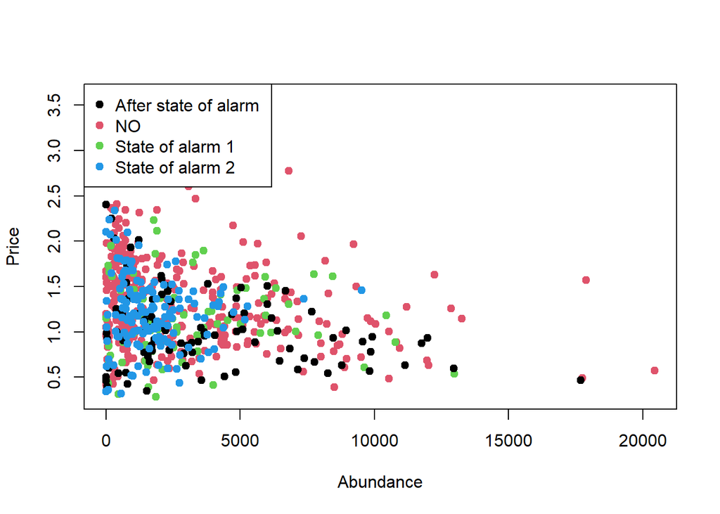

```r
plot(data1$kgs,data1$euros,
     pch = 19,
     col = factor(data1$Covid),xlab="Abundance",ylab = "Price")

# Legend
legend("topleft",
       legend = levels(factor(data1$Covid)),
       pch = 19,
       col = factor(levels(factor(data1$Covid))))
```

```r
cor.test(data1$kgs,data1$euros)
```

```
##
##  Pearson's product-moment correlation
##
## data:  data1$kgs and data1$euros
## t = -5.2251, df = 646, p-value = 2.352e-07
## alternative hypothesis: true correlation is not equal to 0
## 95 percent confidence interval:
##  -0.2741349 -0.1263041
## sample estimates:
##        cor
## -0.2013659
```

Is gamma a correct distribution for the response variable PRICE?

```r
summary(data1$euros)
```

```
##    Min. 1st Qu.  Median    Mean 3rd Qu.    Max.
##  0.2812  0.8980  1.1536  1.2237  1.5077  3.5997
```

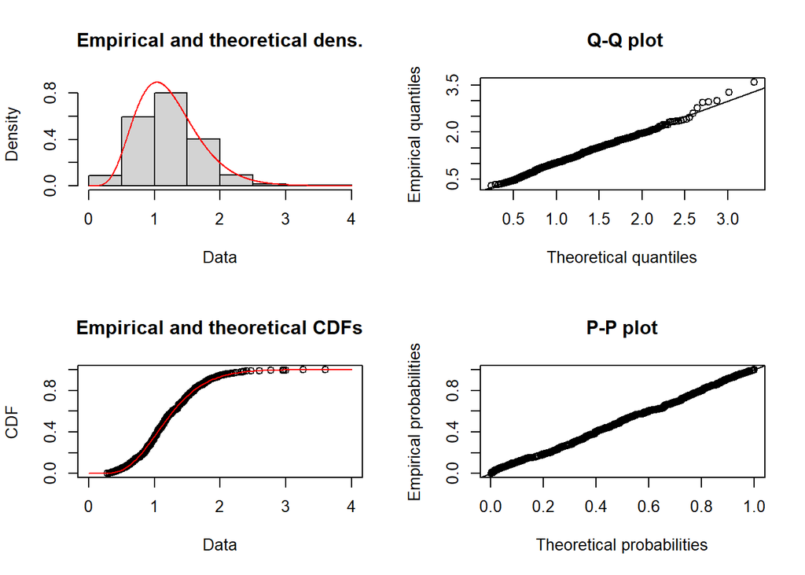

```r
a=fitdist(data1$euros, distr = "gamma",start=list(shape = 1, rate = 2), lower = -1,method = "mme")
plot(a)
```

```r
ks.test(na.omit(data1$euros), "pgamma", a$estimate[1],a$estimate[2])
```

```
##
##  One-sample Kolmogorov-Smirnov test
##
## data:  na.omit(data1$euros)
## D = 0.02725, p-value = 0.7217
## alternative hypothesis: two-sided
```

```r
gamma_test(data1$euros)
```

```
##
##  Test of fit for the Gamma distribution
##
## data:  data1$euros
## V = -0.70055, p-value = 0.6203
```

Is gamma a correct distribution for the response variable ABUNDANCE?

```r
summary(data1$kgs)
```

```
##     Min.  1st Qu.   Median     Mean  3rd Qu.     Max.
##     1.54   657.27  1729.36  2796.49  4007.91 20436.84
```

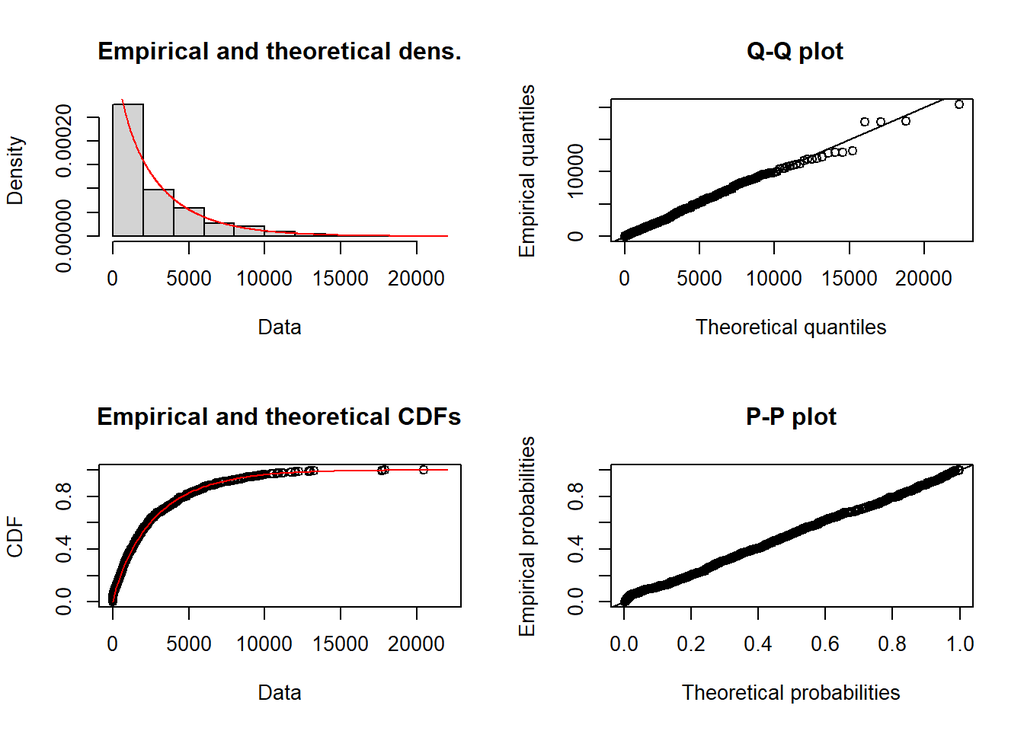

```r
a=fitdist(data1$kgs, distr = "gamma",start=list(shape = 1, rate = 2), lower = -1,method = "mme")
plot(a)
```

```r
ks.test(na.omit(data1$kgs), "pgamma", a$estimate[1],a$estimate[2])
```

```
##
##  One-sample Kolmogorov-Smirnov test
##
## data:  na.omit(data1$kgs)
## D = 0.033133, p-value = 0.4753
## alternative hypothesis: two-sided
```

```r
gamma_test(data1$kgs)
```

```
##
##  Test of fit for the Gamma distribution
##
## data:  data1$kgs
## V = -1.7531, p-value = 0.2151
```

### 2.3.3 Regression model

```r
x=as.factor(data1$Covid)
table(x)
```

```
## x
## After state of alarm                     NO      State of alarm 1
##                    94                   336                    75
##      State of alarm 2
##                   143
```

```r
y=as.numeric(data1$euros)
x=relevel(x, ref = "NO")
z=data1$kgs


Model<-glm((y)~x,family=Gamma(link=log))
cooksd <- cooks.distance(Model)
influential <- cooksd[(cooksd > (3 * mean(cooksd, na.rm = TRUE)))]
influential=as.numeric(names(influential))
y=y[-influential]
xaux=x[-influential]
Model<-glm((y)~xaux,family=Gamma(link=log))
summary(Model)
```

```
##
## Call:
## glm(formula = (y) ~ xaux, family = Gamma(link = log))
##
## Deviance Residuals:
##      Min        1Q    Median        3Q       Max
## -1.04694  -0.24201  -0.03244   0.21312   0.74908
##
## Coefficients:
##                           Estimate Std. Error t value Pr(>|t|)
## (Intercept)                0.23840    0.01773  13.450  < 2e-16 ***
## xauxAfter state of alarm  -0.26813    0.04018  -6.674 5.71e-11 ***
## xauxState of alarm 1      -0.11059    0.04660  -2.373   0.0179 *
## xauxState of alarm 2      -0.05382    0.03311  -1.626   0.1045
## ---
## Signif. codes:  0 '***' 0.001 '**' 0.01 '*' 0.05 '.' 0.1 ' ' 1
##
## (Dispersion parameter for Gamma family taken to be 0.1039925)
##
##     Null deviance: 72.285  on 599  degrees of freedom
## Residual deviance: 67.707  on 596  degrees of freedom
## AIC: 563.73
##
## Number of Fisher Scoring iterations: 4
```

```r
Model.aux<-glm((z)~x,family=Gamma(link=log))

cooksd <- cooks.distance(Model.aux)
influential <- cooksd[(cooksd > (3 * mean(cooksd, na.rm = TRUE)))]
influential=as.numeric(names(influential))
z=z[-influential]
xaux=x[-influential]
Model.aux<-glm((z)~xaux,family=Gamma(link=log))
summary(Model.aux)
```

```
##
## Call:
## glm(formula = (z) ~ xaux, family = Gamma(link = log))
##
## Deviance Residuals:
##     Min       1Q   Median       3Q      Max
## -3.5602  -1.0784  -0.2961   0.4656   1.8069
##
## Coefficients:
##                           Estimate Std. Error t value Pr(>|t|)
## (Intercept)                7.79204    0.05060 153.980  < 2e-16 ***
## xauxAfter state of alarm   0.16234    0.11164   1.454    0.146
## xauxState of alarm 1      -0.02348    0.12254  -0.192    0.848
## xauxState of alarm 2      -0.44654    0.09229  -4.838 1.66e-06 ***
## ---
## Signif. codes:  0 '***' 0.001 '**' 0.01 '*' 0.05 '.' 0.1 ' ' 1
##
## (Dispersion parameter for Gamma family taken to be 0.8220104)
##
##     Null deviance: 869.90  on 607  degrees of freedom
## Residual deviance: 846.01  on 604  degrees of freedom
## AIC: 10600
##
## Number of Fisher Scoring iterations: 6
```

## 2.4 Scomber scombrus

```r
data1=subset(data_A,data_A$specie=="MAC-CABALLA")
```

### 2.4.1 Exploratory analysis

#### 2.4.1.1 Price by covid category (boxplot)

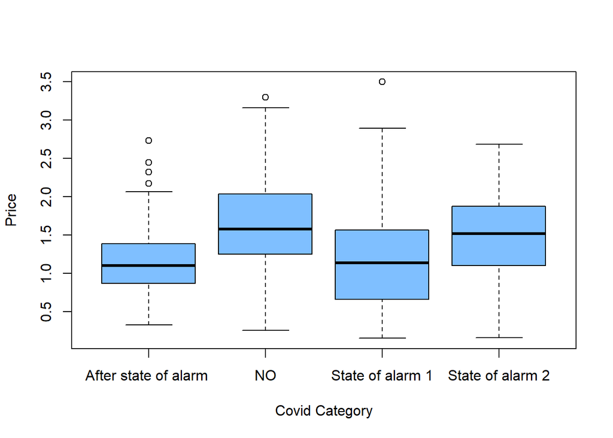

```r
boxplot(data1$euros~data1$Covid, col = rgb(0, 0.5, 1, alpha = 0.5),xlab="Covid Category",ylab="Price")
```

### 2.4.2 Abundance by covid category (boxplot)

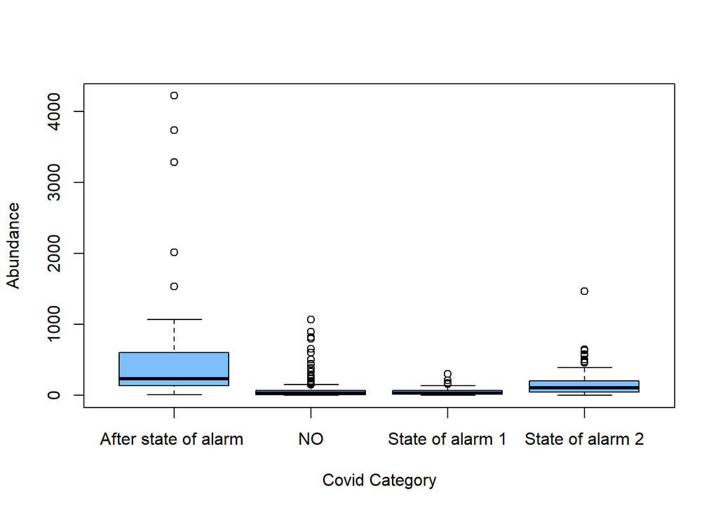

```r
boxplot(data1$kgs~data1$Covid, col = rgb(0, 0.5, 1, alpha = 0.5),xlab="Covid Category",ylab="Abundance")
```

#### 2.4.2.1 Price vs Abundance (scatter plot)

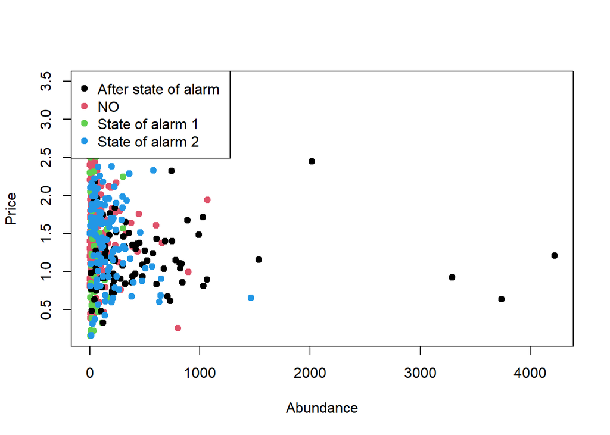

```r
plot(data1$kgs,data1$euros,
     pch = 19,
     col = factor(data1$Covid),xlab="Abundance",ylab = "Price")

# Legend
legend("topleft",
       legend = levels(factor(data1$Covid)),
       pch = 19,
       col = factor(levels(factor(data1$Covid))))
```

```r
cor.test(data1$kgs,data1$euros)
```

```
##
##  Pearson's product-moment correlation
##
## data:  data1$kgs and data1$euros
## t = -2.9959, df = 491, p-value = 0.002875
## alternative hypothesis: true correlation is not equal to 0
## 95 percent confidence interval:
##  -0.21969680 -0.04622026
## sample estimates:
##        cor
## -0.1339848
```

Is gamma a correct distribution for the response variable PRICE?

```r
summary(data1$euros)
```

```
##    Min. 1st Qu.  Median    Mean 3rd Qu.    Max.
##  0.1505  1.0411  1.4283  1.4792  1.8669  3.5000
```

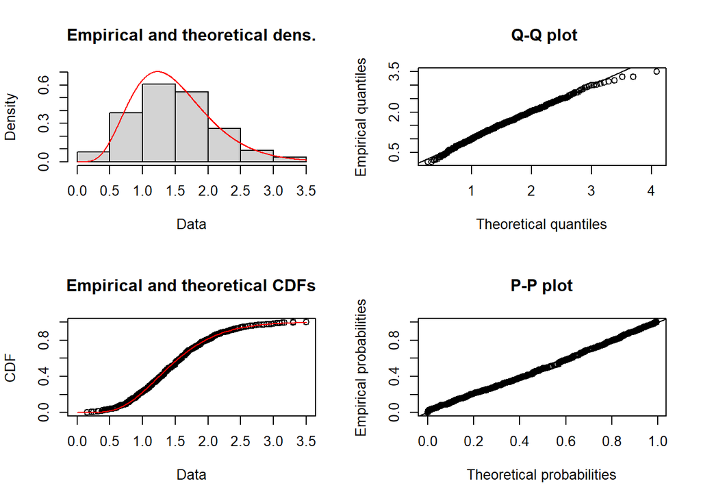

```r
a=fitdist(data1$euros, distr = "gamma",start=list(shape = 1, rate = 2), lower = -1,method = "mme")
plot(a)
```

```r
ks.test(na.omit(data1$euros), "pgamma", a$estimate[1],a$estimate[2])
```

```
##
##  One-sample Kolmogorov-Smirnov test
##
## data:  na.omit(data1$euros)
## D = 0.036785, p-value = 0.5171
## alternative hypothesis: two-sided
```

```r
gamma_test(data1$euros)
```

```
##
##  Test of fit for the Gamma distribution
##
## data:  data1$euros
## V = -4.3631, p-value = 0.002034
```

Is gamma a correct distribution for the response variable ABUNDANCE?

```r
summary(data1$kgs)
```

```
##    Min. 1st Qu.  Median    Mean 3rd Qu.    Max.
##    0.65   19.50   60.35  171.94  180.16 4220.06
```

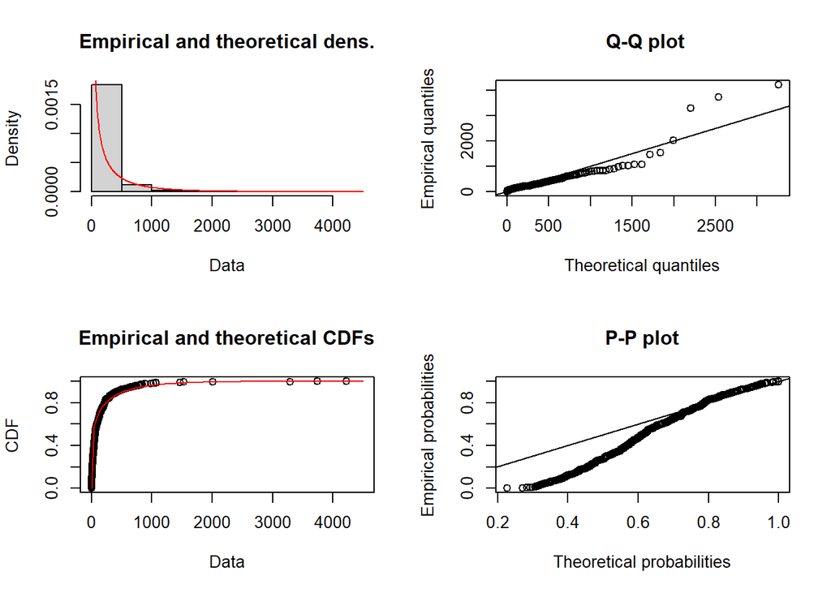

```r
a=fitdist(data1$kgs, distr = "gamma",start=list(shape = 1, rate = 2), lower = -1,method = "mme")
plot(a)
```

```r
ks.test(na.omit(data1$kgs), "pgamma", a$estimate[1],a$estimate[2])
```

```
##
##  One-sample Kolmogorov-Smirnov test
##
## data:  na.omit(data1$kgs)
## D = 0.29661, p-value < 2.2e-16
## alternative hypothesis: two-sided
```

```r
gamma_test(data1$kgs)
```

```
##
##  Test of fit for the Gamma distribution
##
## data:  data1$kgs
## V = 18.971, p-value < 2.2e-16
```

### 2.4.3 Regression model

```r
x=as.factor(data1$Covid)
table(x)
```

```
## x
## After state of alarm                     NO      State of alarm 1
##                    88                   225                    49
##      State of alarm 2
##                   131
```

```r
y=as.numeric(data1$euros)
x=relevel(x, ref = "NO")
z=data1$kgs


Model<-glm((y)~x,family=Gamma(link=log))
cooksd <- cooks.distance(Model)
influential <- cooksd[(cooksd > (3 * mean(cooksd, na.rm = TRUE)))]
influential=as.numeric(names(influential))
y=y[-influential]
xaux=x[-influential]
Model<-glm((y)~xaux,family=Gamma(link=log))
summary(Model)
```

```
##
## Call:
## glm(formula = (y) ~ xaux, family = Gamma(link = log))
##
## Deviance Residuals:
##      Min        1Q    Median        3Q       Max
## -1.44257  -0.27254  -0.02103   0.22191   0.78068
##
## Coefficients:
##                           Estimate Std. Error t value Pr(>|t|)
## (Intercept)                0.50304    0.02322  21.668  < 2e-16 ***
## xauxAfter state of alarm  -0.39997    0.04512  -8.864  < 2e-16 ***
## xauxState of alarm 1      -0.36416    0.06871  -5.300  1.8e-07 ***
## xauxState of alarm 2      -0.11747    0.03846  -3.054  0.00239 **
## ---
## Signif. codes:  0 '***' 0.001 '**' 0.01 '*' 0.05 '.' 0.1 ' ' 1
##
## (Dispersion parameter for Gamma family taken to be 0.121273)
##
##     Null deviance: 74.465  on 463  degrees of freedom
## Residual deviance: 63.717  on 460  degrees of freedom
## AIC: 703.03
##
## Number of Fisher Scoring iterations: 4
```

```r
Model.aux<-glm((z)~x,family=Gamma(link=log))

cooksd <- cooks.distance(Model.aux)
influential <- cooksd[(cooksd > (3 * mean(cooksd, na.rm = TRUE)))]
influential=as.numeric(names(influential))
z=z[-influential]
xaux=x[-influential]
Model.aux<-glm((z)~xaux,family=Gamma(link=log))
summary(Model.aux)
```

```
##
## Call:
## glm(formula = (z) ~ xaux, family = Gamma(link = log))
##
## Deviance Residuals:
##     Min       1Q   Median       3Q      Max
## -2.5815  -0.9959  -0.4310   0.3103   2.7840
##
## Coefficients:
##                           Estimate Std. Error t value Pr(>|t|)
## (Intercept)                3.88799    0.07075  54.951   <2e-16 ***
## xauxAfter state of alarm   2.00533    0.13327  15.048   <2e-16 ***
## xauxState of alarm 1      -0.33748    0.17297  -1.951   0.0517 .
## xauxState of alarm 2       0.99805    0.11623   8.587   <2e-16 ***
## ---
## Signif. codes:  0 '***' 0.001 '**' 0.01 '*' 0.05 '.' 0.1 ' ' 1
##
## (Dispersion parameter for Gamma family taken to be 1.071303)
##
##     Null deviance: 834.19  on 466  degrees of freedom
## Residual deviance: 503.96  on 463  degrees of freedom
## AIC: 5139.1
##
## Number of Fisher Scoring iterations: 6
```

## 2.5 Sardina pilchardus

```r
data1=subset(data_A,data_A$specie=="PIL-SARDINA")
```

### 2.5.1 Exploratory analysis

#### 2.5.1.1 Price by covid category (boxplot)

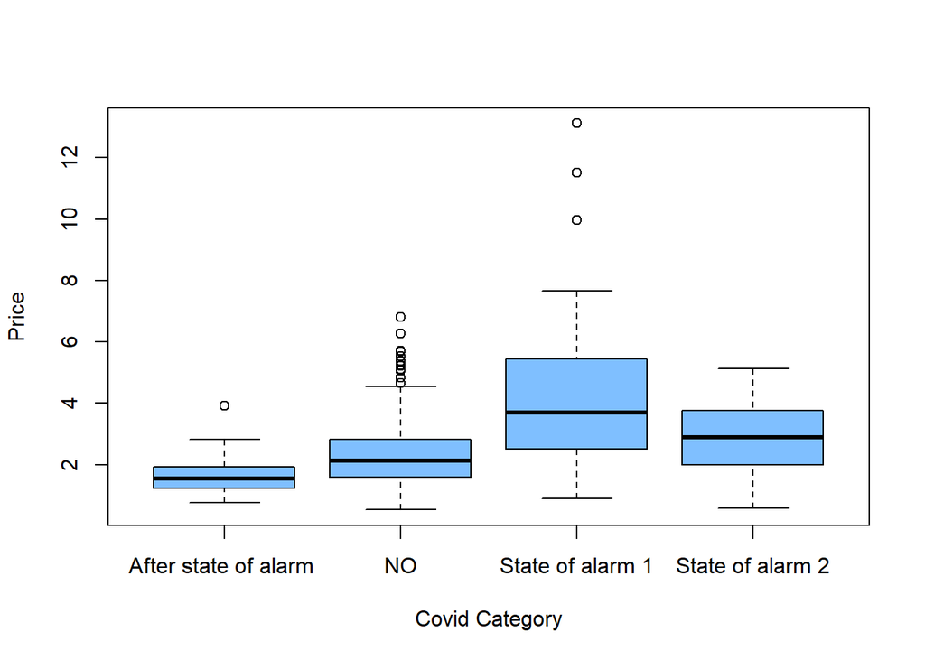

```r
boxplot(data1$euros~data1$Covid, col = rgb(0, 0.5, 1, alpha = 0.5),xlab="Covid Category",ylab="Price")
```

### 2.5.2 Abundance by covid category (boxplot)

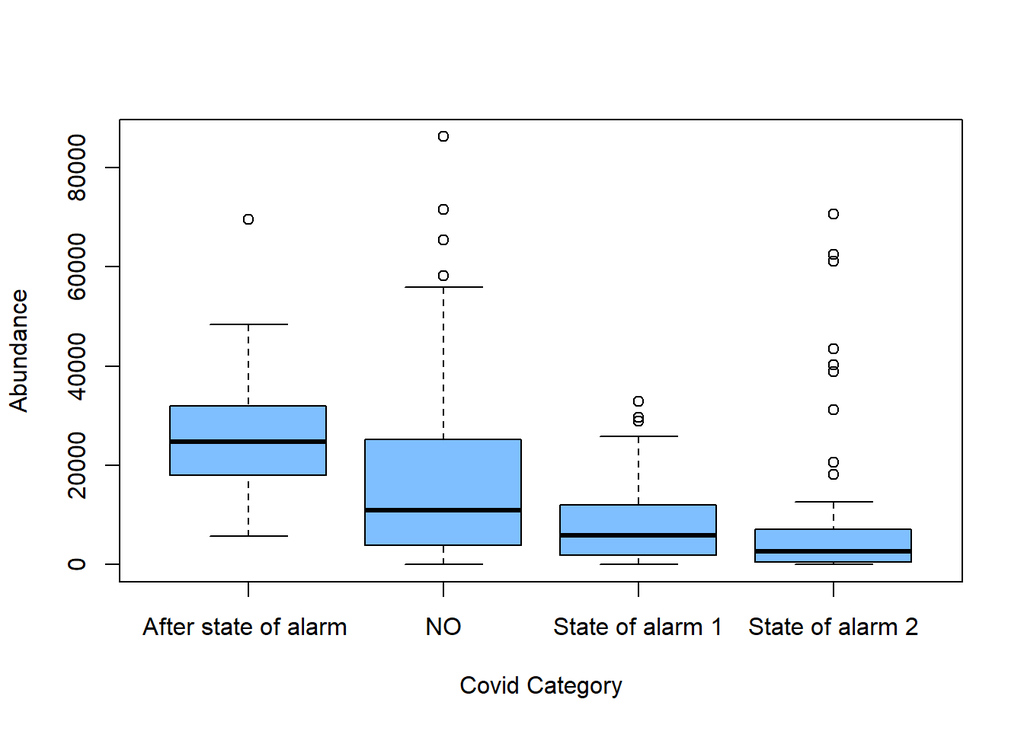

```r
boxplot(data1$kgs~data1$Covid, col = rgb(0, 0.5, 1, alpha = 0.5),xlab="Covid Category",ylab="Abundance")
```

#### 2.5.2.1 Price vs Abundance (scatter plot)

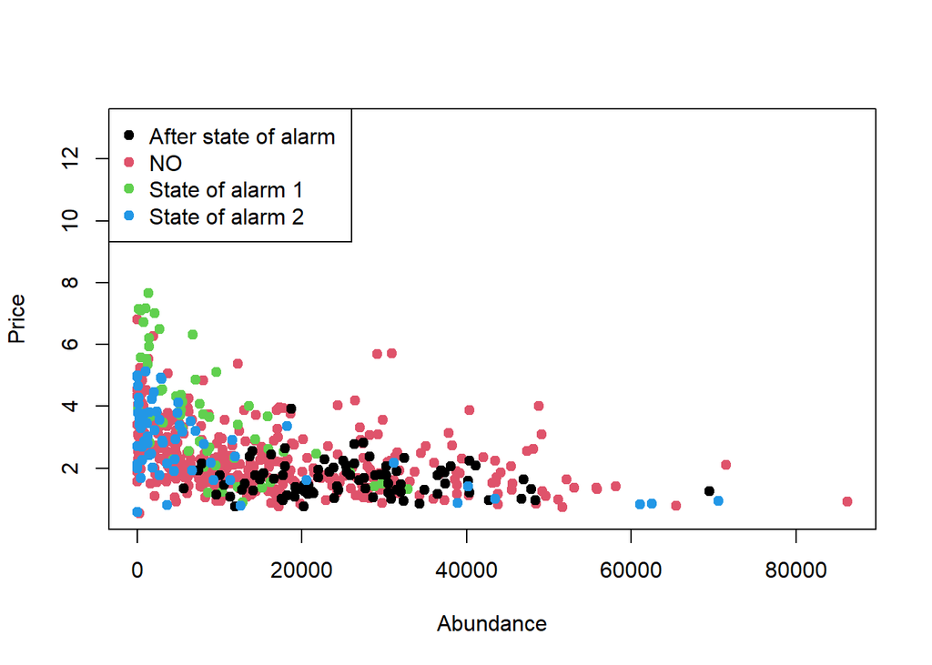

```r
plot(data1$kgs,data1$euros,
     pch = 19,
     col = factor(data1$Covid),xlab="Abundance",ylab = "Price")

# Legend
legend("topleft",
       legend = levels(factor(data1$Covid)),
       pch = 19,
       col = factor(levels(factor(data1$Covid))))
```

```r
cor.test(data1$kgs,data1$euros)
```

```
##
##  Pearson's product-moment correlation
##
## data:  data1$kgs and data1$euros
## t = -11.161, df = 564, p-value < 2.2e-16
## alternative hypothesis: true correlation is not equal to 0
## 95 percent confidence interval:
##  -0.4905562 -0.3553793
## sample estimates:
##       cor
## -0.425337
```

Is gamma a correct distribution for the response variable PRICE?

```r
summary(data1$euros)
```

```
##    Min. 1st Qu.  Median    Mean 3rd Qu.    Max.
##   0.530   1.547   2.149   2.473   3.015  13.118
```

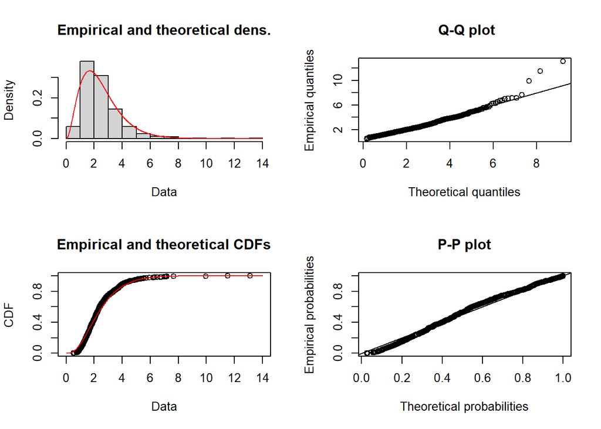

```r
a=fitdist(data1$euros, distr = "gamma",start=list(shape = 1, rate = 2), lower = -1,method = "mme")
plot(a)
```

```r
ks.test(na.omit(data1$euros), "pgamma", a$estimate[1],a$estimate[2])
```

```
##
##  One-sample Kolmogorov-Smirnov test
##
## data:  na.omit(data1$euros)
## D = 0.064147, p-value = 0.01897
## alternative hypothesis: two-sided
```

```r
gamma_test(data1$euros)
```

```
##
##  Test of fit for the Gamma distribution
##
## data:  data1$euros
## V = 10.324, p-value = 2.877e-13
```

Is gamma a correct distribution for the response variable ABUNDANCE?

```r
summary(data1$kgs)
```

```
##    Min. 1st Qu.  Median    Mean 3rd Qu.    Max.
##     4.5  3669.3 11330.2 15688.9 25121.2 86258.6
```

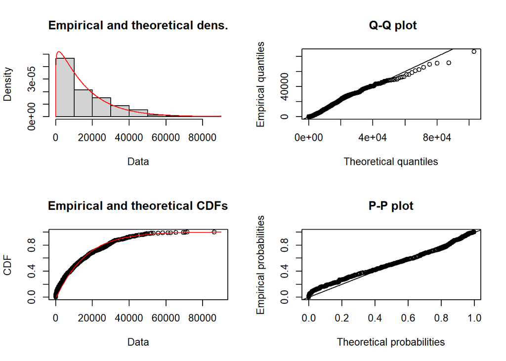

```r
a=fitdist(data1$kgs, distr = "gamma",start=list(shape = 1, rate = 2), lower = -1,method = "mme")
plot(a)
```

```r
ks.test(na.omit(data1$kgs), "pgamma", a$estimate[1],a$estimate[2])
```

```
##
##  One-sample Kolmogorov-Smirnov test
##
## data:  na.omit(data1$kgs)
## D = 0.082581, p-value = 0.0008878
## alternative hypothesis: two-sided
```

```r
gamma_test(data1$kgs)
```

```
##
##  Test of fit for the Gamma distribution
##
## data:  data1$kgs
## V = -5.7967, p-value = 4.152e-05
```

### 2.5.3 Regression model

```r
x=as.factor(data1$Covid)
table(x)
```

```
## x
## After state of alarm                     NO      State of alarm 1
##                    86                   354                    60
##      State of alarm 2
##                    66
```

```r
y=as.numeric(data1$euros)
x=relevel(x, ref = "NO")
z=data1$kgs


Model<-glm((y)~x,family=Gamma(link=log))
cooksd <- cooks.distance(Model)
influential <- cooksd[(cooksd > (3 * mean(cooksd, na.rm = TRUE)))]
influential=as.numeric(names(influential))
y=y[-influential]
xaux=x[-influential]
Model<-glm((y)~xaux,family=Gamma(link=log))
summary(Model)
```

```
##
## Call:
## glm(formula = (y) ~ xaux, family = Gamma(link = log))
##
## Deviance Residuals:
##      Min        1Q    Median        3Q       Max
## -1.17251  -0.30851  -0.04781   0.19765   0.96983
##
## Coefficients:
##                           Estimate Std. Error t value Pr(>|t|)
## (Intercept)                0.81877    0.02034  40.245  < 2e-16 ***
## xauxAfter state of alarm  -0.37608    0.04659  -8.072 4.88e-15 ***
## xauxState of alarm 1       0.49169    0.06409   7.672 8.50e-14 ***
## xauxState of alarm 2       0.23456    0.05691   4.122 4.38e-05 ***
## ---
## Signif. codes:  0 '***' 0.001 '**' 0.01 '*' 0.05 '.' 0.1 ' ' 1
##
## (Dispersion parameter for Gamma family taken to be 0.1440407)
##
##     Null deviance: 98.602  on 519  degrees of freedom
## Residual deviance: 74.406  on 516  degrees of freedom
## AIC: 1264.8
##
## Number of Fisher Scoring iterations: 4
```

```r
Model.aux<-glm((z)~x,family=Gamma(link=log))

cooksd <- cooks.distance(Model.aux)
influential <- cooksd[(cooksd > (3 * mean(cooksd, na.rm = TRUE)))]
influential=as.numeric(names(influential))
z=z[-influential]
xaux=x[-influential]
Model.aux<-glm((z)~xaux,family=Gamma(link=log))
summary(Model.aux)
```

```
##
## Call:
## glm(formula = (z) ~ xaux, family = Gamma(link = log))
##
## Deviance Residuals:
##     Min       1Q   Median       3Q      Max
## -3.7802  -1.0085  -0.2148   0.3983   2.3189
##
## Coefficients:
##                           Estimate Std. Error t value Pr(>|t|)
## (Intercept)                9.64889    0.04678  206.25  < 2e-16 ***
## xauxAfter state of alarm   0.48691    0.10608    4.59 5.50e-06 ***
## xauxState of alarm 1      -0.90101    0.12726   -7.08 4.46e-12 ***
## xauxState of alarm 2      -1.52128    0.12438  -12.23  < 2e-16 ***
## ---
## Signif. codes:  0 '***' 0.001 '**' 0.01 '*' 0.05 '.' 0.1 ' ' 1
##
## (Dispersion parameter for Gamma family taken to be 0.7703979)
##
##     Null deviance: 861.45  on 549  degrees of freedom
## Residual deviance: 719.13  on 546  degrees of freedom
## AIC: 11535
##
## Number of Fisher Scoring iterations: 7
```

## 2.6 Scomber colias

```r
data1=subset(data_A,data_A$specie=="VMA-CABALLA DEL SUR O TONINO")
```

### 2.6.1 Exploratory analysis

#### 2.6.1.1 Price by covid category (boxplot)

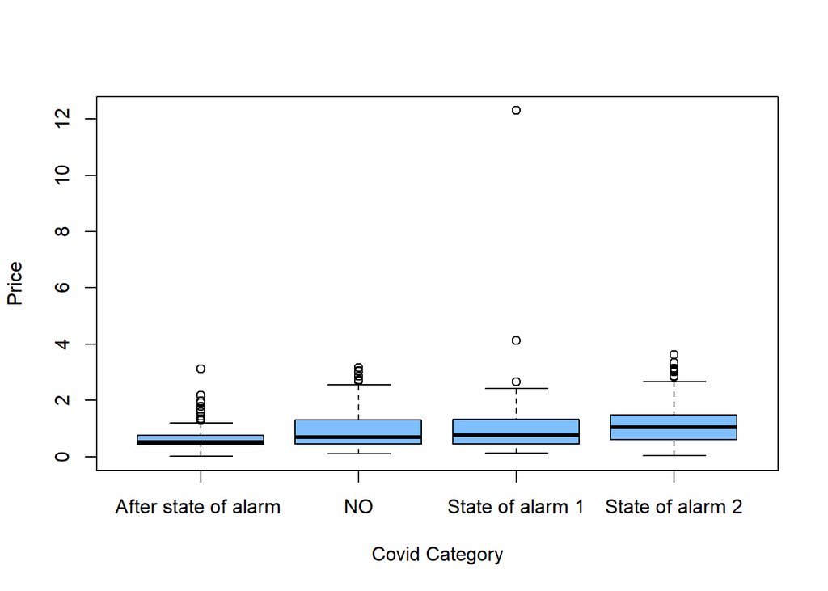

```r
boxplot(data1$euros~data1$Covid, col = rgb(0, 0.5, 1, alpha = 0.5),xlab="Covid Category",ylab="Price")
```

### 2.6.2 Abundance by covid category (boxplot)

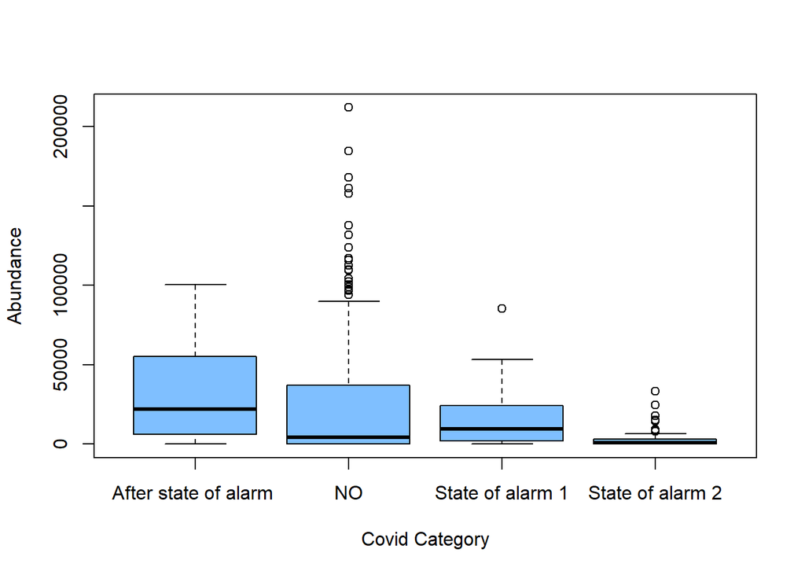

```r
boxplot(data1$kgs~data1$Covid, col = rgb(0, 0.5, 1, alpha = 0.5),xlab="Covid Category",ylab="Abundance")
```

#### 2.6.2.1 Price vs Abundance (scatter plot)

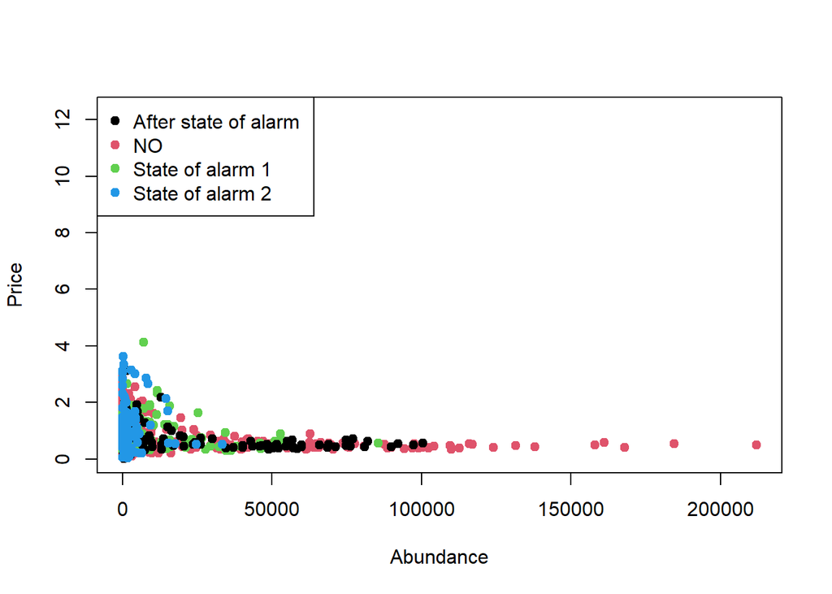

```r
plot(data1$kgs,data1$euros,
     pch = 19,
     col = factor(data1$Covid),xlab="Abundance",ylab = "Price")

# Legend
legend("topleft",
       legend = levels(factor(data1$Covid)),
       pch = 19,
       col = factor(levels(factor(data1$Covid))))
```

```r
cor.test(data1$kgs,data1$euros)
```

```
##
##  Pearson's product-moment correlation
##
## data:  data1$kgs and data1$euros
## t = -7.8499, df = 522, p-value = 2.378e-14
## alternative hypothesis: true correlation is not equal to 0
## 95 percent confidence interval:
##  -0.3994747 -0.2461296
## sample estimates:
##        cor
## -0.3249362
```

Is gamma a correct distribution for the response variable PRICE?

```r
summary(data1$euros)
```

```
##     Min.  1st Qu.   Median     Mean  3rd Qu.     Max.
##  0.01001  0.45934  0.70403  0.97520  1.26943 12.30208
```

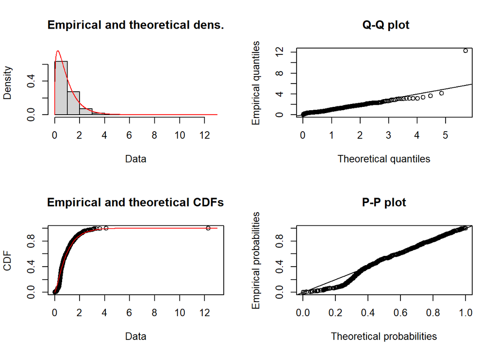

```r
a=fitdist(data1$euros, distr = "gamma",start=list(shape = 1, rate = 2), lower = -1,method = "mme")
plot(a)
```

```r
ks.test(na.omit(data1$euros), "pgamma", a$estimate[1],a$estimate[2])
```

```
##
##  One-sample Kolmogorov-Smirnov test
##
## data:  na.omit(data1$euros)
## D = 0.14623, p-value = 3.702e-10
## alternative hypothesis: two-sided
```

```r
gamma_test(data1$euros)
```

```
##
##  Test of fit for the Gamma distribution
##
## data:  data1$euros
## V = 13.069, p-value < 2.2e-16
```

Is gamma a correct distribution for the response variable ABUNDANCE?

```r
summary(data1$kgs)
```

```
##     Min.  1st Qu.   Median     Mean  3rd Qu.     Max.
##      0.9    313.2   4670.5  20961.5  31566.4 212006.8
```

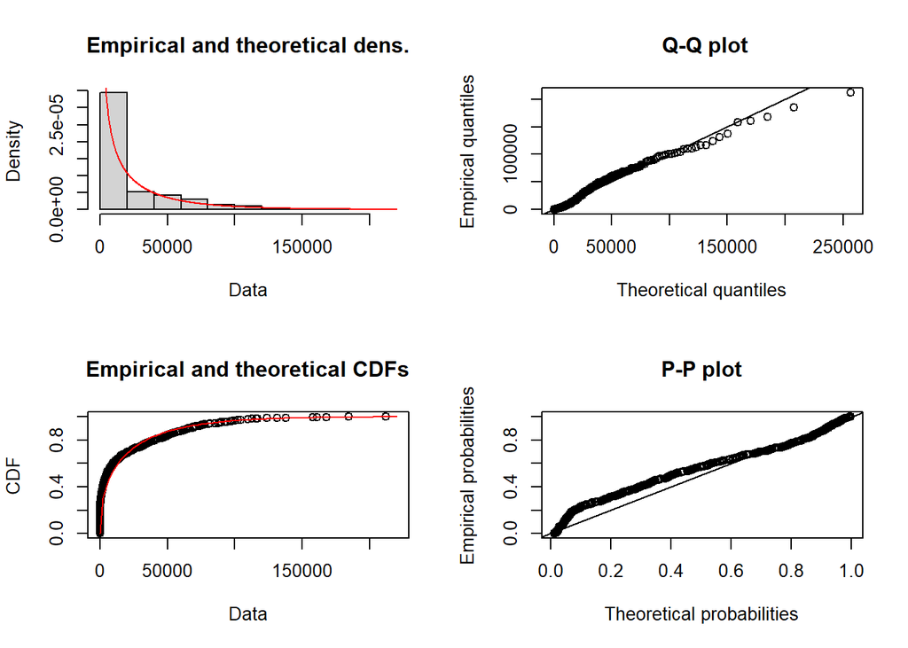

```r
a=fitdist(data1$kgs, distr = "gamma",start=list(shape = 1, rate = 2), lower = -1,method = "mme")
plot(a)
```

```r
ks.test(na.omit(data1$kgs), "pgamma", a$estimate[1],a$estimate[2])
```

```
##
##  One-sample Kolmogorov-Smirnov test
##
## data:  na.omit(data1$kgs)
## D = 0.13066, p-value = 3.394e-08
## alternative hypothesis: two-sided
```

```r
gamma_test(data1$kgs)
```

```
##
##  Test of fit for the Gamma distribution
##
## data:  data1$kgs
## V = -3.0065, p-value = 0.03351
```

### 2.6.3 Regression model

```r
x=as.factor(data1$Covid)
table(x)
```

```
## x
## After state of alarm                     NO      State of alarm 1
##                    86                   276                    67
##      State of alarm 2
##                    95
```

```r
y=as.numeric(data1$euros)
x=relevel(x, ref = "NO")
z=data1$kgs


Model<-glm((y)~x,family=Gamma(link=log))
cooksd <- cooks.distance(Model)
influential <- cooksd[(cooksd > (3 * mean(cooksd, na.rm = TRUE)))]
influential=as.numeric(names(influential))
y=y[-influential]
xaux=x[-influential]
Model<-glm((y)~xaux,family=Gamma(link=log))
summary(Model)
```

```
##
## Call:
## glm(formula = (y) ~ xaux, family = Gamma(link = log))
##
## Deviance Residuals:
##     Min       1Q   Median       3Q      Max
## -2.4986  -0.5878  -0.1936   0.2944   1.4733
##
## Coefficients:
##                           Estimate Std. Error t value Pr(>|t|)
## (Intercept)               -0.06473    0.03804  -1.701   0.0895 .
## xauxAfter state of alarm  -0.43488    0.08014  -5.426 8.97e-08 ***
## xauxState of alarm 1      -0.07434    0.08812  -0.844   0.3993
## xauxState of alarm 2       0.07108    0.07760   0.916   0.3601
## ---
## Signif. codes:  0 '***' 0.001 '**' 0.01 '*' 0.05 '.' 0.1 ' ' 1
##
## (Dispersion parameter for Gamma family taken to be 0.3980171)
##
##     Null deviance: 227.89  on 504  degrees of freedom
## Residual deviance: 215.37  on 501  degrees of freedom
## AIC: 701.12
##
## Number of Fisher Scoring iterations: 5
```

```r
Model.aux<-glm((z)~x,family=Gamma(link=log))

cooksd <- cooks.distance(Model.aux)
influential <- cooksd[(cooksd > (3 * mean(cooksd, na.rm = TRUE)))]
influential=as.numeric(names(influential))
z=z[-influential]
xaux=x[-influential]
Model.aux<-glm((z)~xaux,family=Gamma(link=log))
summary(Model.aux)
```

```
##
## Call:
## glm(formula = (z) ~ xaux, family = Gamma(link = log))
##
## Deviance Residuals:
##     Min       1Q   Median       3Q      Max
## -4.2474  -2.3718  -0.8067   0.5289   2.3971
##
## Coefficients:
##                           Estimate Std. Error t value Pr(>|t|)
## (Intercept)                9.91487    0.07903 125.459   <2e-16 ***
## xauxAfter state of alarm   0.41579    0.16132   2.577   0.0102 *
## xauxState of alarm 1      -0.58819    0.18421  -3.193   0.0015 **
## xauxState of alarm 2      -2.65276    0.15919 -16.664   <2e-16 ***
## ---
## Signif. codes:  0 '***' 0.001 '**' 0.01 '*' 0.05 '.' 0.1 ' ' 1
##
## (Dispersion parameter for Gamma family taken to be 1.661307)
##
##     Null deviance: 2130.6  on 496  degrees of freedom
## Residual deviance: 1805.9  on 493  degrees of freedom
## AIC: 9900.2
##
## Number of Fisher Scoring iterations: 13
```

## 2.7 Micromesistius poutassou

```r
data1=subset(data_A,data_A$specie=="WHB-BACALADILLA")
```

### 2.7.1 Exploratory analysis

#### 2.7.1.1 Price by covid category (boxplot)

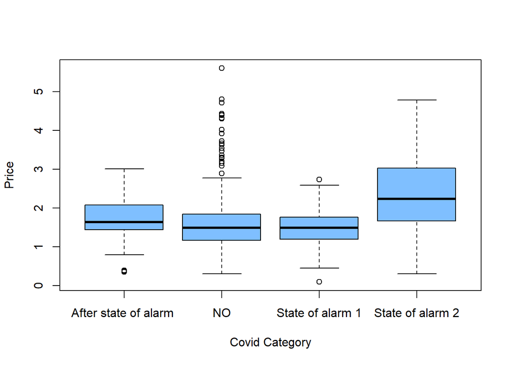

```r
boxplot(data1$euros~data1$Covid, col = rgb(0, 0.5, 1, alpha = 0.5),xlab="Covid Category",ylab="Price")
```

### 2.7.2 Abundance by covid category (boxplot)

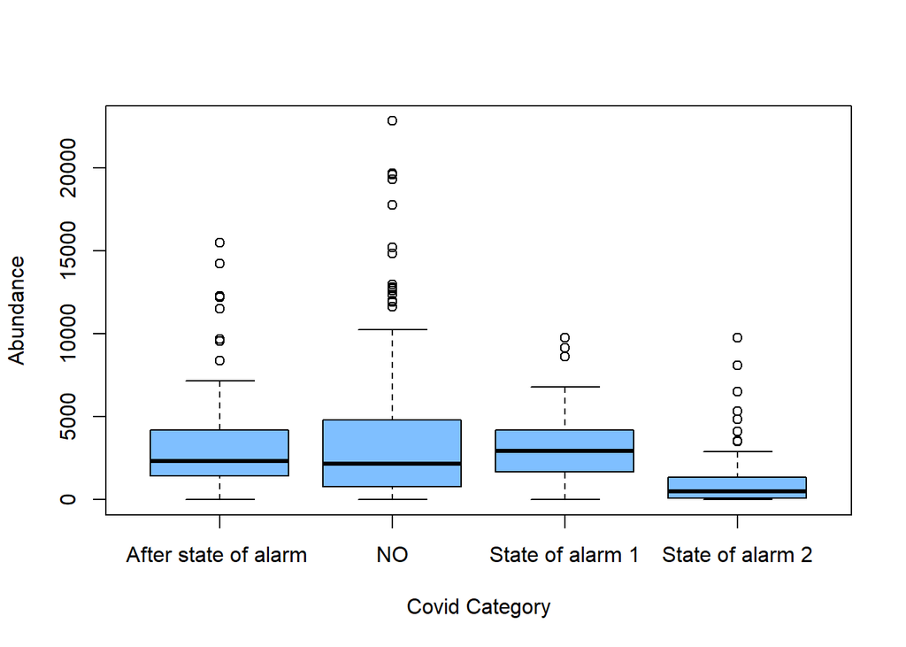

```r
boxplot(data1$kgs~data1$Covid, col = rgb(0, 0.5, 1, alpha = 0.5),xlab="Covid Category",ylab="Abundance")
```